# Assignment 5 - Bike Share Demand Forecasting

Anaushka Goyal

April 11, 2025

# 1. Introduction to Bike Share and Rebalancing Plan

## 1.1 Bikshare Syatems- Capital Bikeshare DC

Capital Bikeshare in Washington, DC makes it easy for people to grab a bike, ride where they need to go, and drop it off at another station. It’s a simple, affordable way to get around without needing a car. Bike-share systems like this help cut down traffic, reduce pollution, and make it easier for everyone to move around the city.

## 1.2 Operational Challenges Faced by Bike-Share Systems:

One of the biggest challenges for bike-share systems is making sure there are always enough bikes to pick up and enough empty docks to return bikes. If a station runs out of bikes or gets completely full, it becomes frustrating for users. To keep things running smoothly, bike-share operators have to constantly move bikes around the city based on where they think people will need them next.

## 1.3 Rebalancing Problem

Rebalancing ensure bike availability across all docks so that demand can be met without any lags or hiccups. It involved manually redistributing bikes across stations to ensure bike and dock availability. For the same, it required anticipating demand for all docks at all times, which is a problem hence advanced models to accurately predict demand using historical data are used here. The following model also forecasts space/time demand for bike share pickup in Washington DC’s Capital Bikeshare, using May 2019 data.

## 1.4 Proposed Rebalancing Strategy:

I plan to use a small fleet of trucks to move bikes between stations based on where we expect demand to be in the next 2 to 3 hours. The predictions use information like the time of day, day of the week, weather (like temperature and rain), and whether it’s a holiday. We also look at how busy each station has been recently by using past trip counts. This way, we can send trucks to the right places before stations run out of bikes or get too full. On weekends or during special events, we could also offer discounts or rewards to riders to help move bikes when predictions are less certain.

## 1.5 Load Libraries

```r
library(tidyverse)
library(sf)
library(lubridate)
library(tigris)
library(tidycensus)
library(viridis)
library(riem)
library(gridExtra)
library(knitr)
library(kableExtra)
library(RSocrata)
library(dplyr)

plotTheme <- theme(
  plot.title =element_text(size=12),
  plot.subtitle = element_text(size=8),
  plot.caption = element_text(size = 6),
  axis.text.x = element_text(size = 10, angle = 45, hjust = 1),
  axis.text.y = element_text(size = 10),
  axis.title.y = element_text(size = 10),
  # Set the entire chart region to blank
  panel.background=element_blank(),
  plot.background=element_blank(),
  #panel.border=element_rect(colour="#F0F0F0"),
  # Format the grid
  panel.grid.major=element_line(colour="#D0D0D0",size=.2),
  axis.ticks=element_blank())

mapTheme <- theme(plot.title =element_text(size=12),
                  plot.subtitle = element_text(size=8),
                  plot.caption = element_text(size = 6),
                  axis.line=element_blank(),
                  axis.text.x=element_blank(),
                  axis.text.y=element_blank(),
                  axis.ticks=element_blank(),
                  axis.title.x=element_blank(),
                  axis.title.y=element_blank(),
                  panel.background=element_blank(),
                  panel.border=element_blank(),
                  panel.grid.major=element_line(colour = 'transparent'),
                  panel.grid.minor=element_blank(),
                  legend.direction = "vertical",
                  legend.position = "right",
                  plot.margin = margin(1, 1, 1, 1, 'cm'),
                  legend.key.height = unit(1, "cm"), legend.key.width = unit(0.2, "cm"))

palette5 <- c("#fee5d9", "#fcae91", "#fb6a4a", "#de2d26", "#a50f15")
palette4 <- c("#fee0d2", "#fc9272", "#de2d26", "#a50f15")
palette2 <- c("#fb6a4a", "#a50f15")
```

## 1.6 Install Census API Key

```r
# Install Census API Key
tidycensus::census_api_key("02524912081801068f04f286a086d19e9fc641ca", overwrite = TRUE)
```

## 1.7 Load and Clean Bike and Station Data

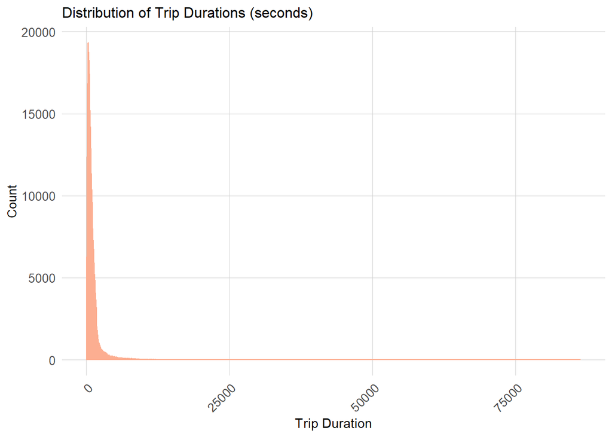

```r
dat_bike <- st_read("Capital_Bikeshare_Locations.geojson")
dat_bi_wa <- st_read("201905-capitalbikeshare-tripdata.csv")

glimpse(dat_bike) #spatial station data
glimpse(dat_bi_wa) #trips data

start_st <- dat_bike %>%
  select(NAME, geometry)

end_st<- dat_bike %>%
  select(NAME, geometry)

##making data spatial by adding point data of start and end station to the trips data

dat <- dat_bi_wa %>%
  left_join(start_st, by = c("Start.station" = "NAME")) %>%
  rename(start_geo = geometry) %>%
  left_join(end_st, by = c("End.station" = "NAME")) %>%
  rename(end_geo = geometry)

dat %>% ##Checking for missing values
  summarise_all(~ sum(is.na(.))) %>%
  gather(key = "variable", value = "num_missing") %>%
  filter(num_missing > 0) %>%
  arrange(desc(num_missing)) %>%
  kable(caption = "Number of Missing Values per Column") %>%
  kable_styling(full_width = FALSE)


# Outlier detection: Trip duration
dat %>%
  mutate(Duration = as.numeric(Duration)) %>%
  ggplot(aes(x = Duration)) +
  geom_histogram(binwidth = 60, fill = "#a50f15", color = "#fcae91") +
  labs(title = "Distribution of Trip Durations (seconds)", x = "Trip Duration", y = "Count") +
  plotTheme
```

```r
# Remove entries with missing station names or extremely long trips (likely errors)
dat <- dat %>%
  filter(!is.na(Start.station) & !is.na(End.station)) %>%
  filter(Duration > 60 & Duration < 7200)  # Keeping trips between 1 minute and 2 hours
```

# 2. Data Preprocessing and Feature Engineering

## 2.1 Feature Engineering

### 2.1.1 Time Bins

Creating 15 and 60 minute intervals by rounding.

```r
dat2 <- dat %>%
  mutate(
    interval60 = floor_date(ymd_hms(Start.date), unit = "hour"),
    interval15 = floor_date(ymd_hms(Start.date), unit = "15 mins"),
    week = week(interval60),
    dotw = wday(interval60, label = TRUE)
  )

glimpse(dat2)
```

```
## Rows: 337,704
## Columns: 15
## $ Duration             <chr> "653", "297", "129", "1119", "533", "895", "489",…
## $ Start.date           <chr> "2019-05-01 00:00:02", "2019-05-01 00:00:13", "20…
## $ End.date             <chr> "2019-05-01 00:10:55", "2019-05-01 00:05:11", "20…
## $ Start.station.number <chr> "31127", "31641", "31255", "31655", "31203", "316…
## $ Start.station        <chr> "22nd & H St NW", "2nd St & Massachusetts Ave NE"…
## $ End.station.number   <chr> "31202", "31603", "31237", "31244", "31223", "315…
## $ End.station          <chr> "14th & R St NW", "1st & M St NE", "25th St & Pen…
## $ Bike.number          <chr> "W00233", "W00555", "W23383", "W20337", "W23707",…
## $ Member.type          <chr> "Member", "Member", "Member", "Member", "Member",…
## $ start_geo            <POINT [°]> POINT (-77.04886 38.89893), POINT (-77.0031…
## $ end_geo              <POINT [°]> POINT (-77.03201 38.91305), POINT (-77.0054…
## $ interval60           <dttm> 2019-05-01, 2019-05-01, 2019-05-01, 2019-05-01, …
## $ interval15           <dttm> 2019-05-01 00:00:00, 2019-05-01 00:00:00, 2019-0…
## $ week                 <dbl> 18, 18, 18, 18, 18, 18, 18, 18, 18, 18, 18, 18, 1…
## $ dotw                 <ord> Wed, Wed, Wed, Wed, Wed, Wed, Wed, Wed, Wed, Wed,…
```

### 2.1.2 Census Data

Getting variables influencing demand from census data-

```r
dcCensus <-
  get_acs(geography = "tract",
          variables = c("B01003_001", "B19013_001",
                        "B02001_002", "B08013_001",
                        "B08012_001", "B08301_001",
                        "B08301_010", "B01002_001"),
          year = 2017,
          state = "DC",   # ← changed to DC
          geometry = TRUE,
          county = NULL,  # ← DC is a state + city, no county needed
          output = "wide") %>%
  rename(Total_Pop =  B01003_001E,
         Med_Inc = B19013_001E,
         Med_Age = B01002_001E,
         White_Pop = B02001_002E,
         Travel_Time = B08013_001E,
         Num_Commuters = B08012_001E,
         Means_of_Transport = B08301_001E,
         Total_Public_Trans = B08301_010E) %>%
  select(Total_Pop, Med_Inc, White_Pop, Travel_Time,
         Means_of_Transport, Total_Public_Trans,
         Med_Age,
         GEOID, geometry) %>%
  mutate(Percent_White = White_Pop / Total_Pop,
         Mean_Commute_Time = Travel_Time / Total_Public_Trans,
         Percent_Taking_Public_Trans = Total_Public_Trans / Means_of_Transport)
```

Extract Geometries-

```r
dcTracts <-
  dcCensus %>%
  as.data.frame() %>%
  distinct(GEOID, .keep_all = TRUE) %>%
  select(GEOID, geometry) %>%
  st_sf()
```

Adding the spatial information to our rideshare data as origin and destination data-

```r
dat2 <- dat2 %>%
  mutate(
    from_longitude = st_coordinates(start_geo)[, 1],
    from_latitude = st_coordinates(start_geo)[, 2],
    to_longitude = st_coordinates(end_geo)[, 1],
    to_latitude = st_coordinates(end_geo)[, 2]
  )


dat_census <- dat2 %>%
  filter(!is.na(from_longitude) &
         !is.na(from_latitude) &
         !is.na(to_longitude) &
         !is.na(to_latitude)) %>%
  st_as_sf(coords = c("from_longitude", "from_latitude"), crs = 4326) %>%
  st_join(
    dcTracts %>% st_transform(crs = 4326),
    join = st_intersects,
    left = TRUE
  ) %>%
  rename(Origin.Tract = GEOID) %>%
  mutate(
    from_longitude = unlist(map(geometry, 1)),
    from_latitude = unlist(map(geometry, 2))
  ) %>%
  as.data.frame() %>%
  select(-geometry) %>%
  st_as_sf(coords = c("to_longitude", "to_latitude"), crs = 4326) %>%
  st_join(
    dcTracts %>% st_transform(crs = 4326),
    join = st_intersects,
    left = TRUE
  ) %>%
  rename(Destination.Tract = GEOID) %>%
  mutate(
    to_longitude = unlist(map(geometry, 1)),
    to_latitude = unlist(map(geometry, 2))
  ) %>%
  as.data.frame() %>%
  select(-geometry)
```

### 2.1.3 Weather Data

```r
weather.Panel <-
  riem_measures(station = "DCA", date_start = "2019-05-01", date_end = "2019-05-31") %>%
  dplyr::select(valid, tmpf, p01i, sknt) %>%
  replace(is.na(.), 0) %>%
  mutate(interval60 = ymd_h(substr(valid, 1, 13))) %>%
  mutate(
    week = week(interval60),
    dotw = wday(interval60, label = TRUE)
  ) %>%
  group_by(interval60) %>%
  summarize(
    Temperature = max(tmpf),
    Precipitation = sum(p01i),
    Wind_Speed = max(sknt)
  ) %>%
  mutate(
    Temperature = ifelse(Temperature == 0, 42, Temperature)
  )


glimpse(weather.Panel)
```

```
## Rows: 720
## Columns: 4
## $ interval60    <dttm> 2019-05-01 00:00:00, 2019-05-01 01:00:00, 2019-05-01 02…
## $ Temperature   <dbl> 75, 71, 69, 70, 67, 64, 63, 62, 61, 61, 60, 60, 60, 60, …
## $ Precipitation <dbl> 0, 0, 0, 0, 0, 0, 0, 0, 0, 0, 0, 0, 0, 0, 0, 0, 0, 0, 0,…
## $ Wind_Speed    <dbl> 7, 7, 7, 7, 10, 12, 13, 8, 10, 8, 10, 10, 10, 8, 8, 6, 5…
```

Plotting Weather Data for Washington DC-

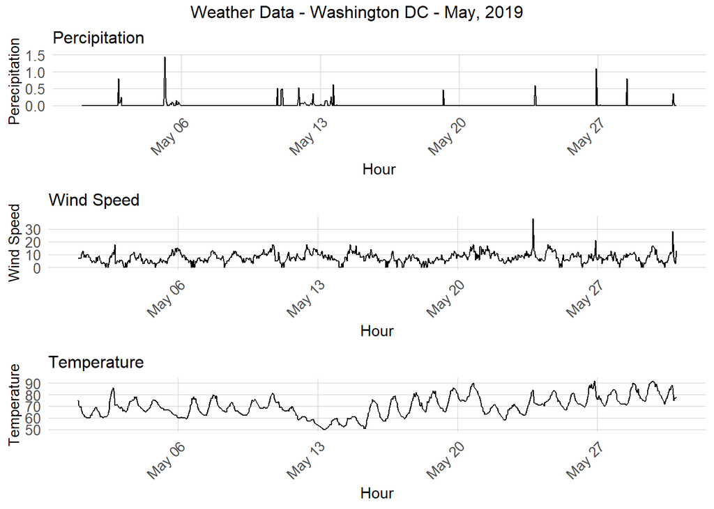

```r
grid.arrange(
  ggplot(weather.Panel, aes(interval60,Precipitation)) + geom_line() +
  labs(title="Percipitation", x="Hour", y="Perecipitation") + plotTheme,
  ggplot(weather.Panel, aes(interval60,Wind_Speed)) + geom_line() +
    labs(title="Wind Speed", x="Hour", y="Wind Speed") + plotTheme,
  ggplot(weather.Panel, aes(interval60,Temperature)) + geom_line() +
    labs(title="Temperature", x="Hour", y="Temperature") + plotTheme,
  top="Weather Data - Washington DC - May, 2019")
```

## 2.2 Exploratory data analysis

### 2.2.1 Bike share trips per hr. Washington DC for all of May, 2019

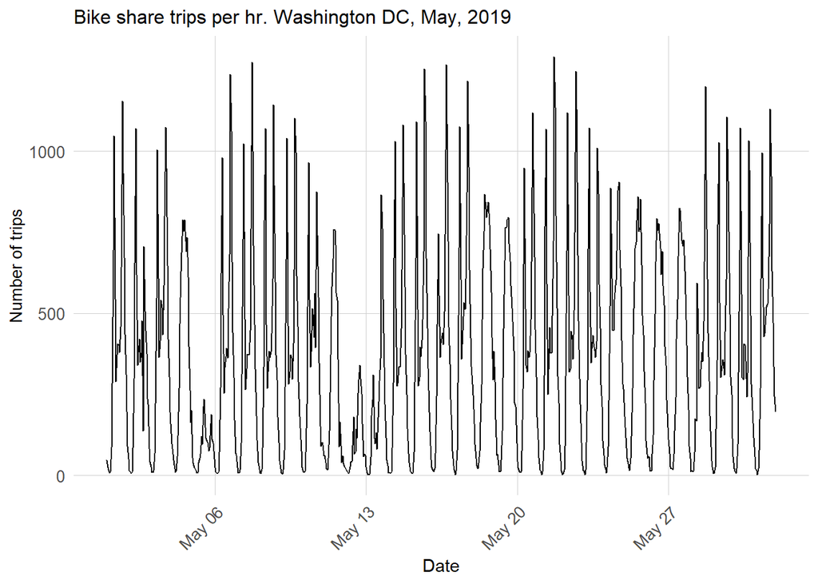

```r
ggplot(dat_census %>%
         group_by(interval60) %>%
         tally())+
  geom_line(aes(x = interval60, y = n))+
  labs(title="Bike share trips per hr. Washington DC, May, 2019",
       x="Date",
       y="Number of trips")+
  plotTheme
```

The above graph shows the demand pattern in DC during the 4 weeks of May, with high ridership during the week and general low rideship during weekends. The graph also shows a big fluctuation in demand during the week with lower demand on Mondays and higher demand during the week.